# Oracle_test

Jordan Watson

5/30/2021

**Oracle database queries**

Some data users prefer the flexibility and transparency of querying raw gridded data directly from the Oracle server. This is particularly useful for larger queries (e..g, millions of records) or for exploring data across a suite of different spatial extents (e.g., custom depth ranges, shapefiles, etc.). As we note in the web services section, such custom queries can also be automated by working with AFSC and AKFIN staff. However, for users that prefer to code their own queries, we provide several examples here. Notably, to query directly from the database, users will need an AKFIN database account, which can be provided by contacting the authors of this document.

This section is not meant to serve as a SQL tutorial. Rather, its purpose is to orient users to the structure of the database related to the SST data and lookup tables. We assume that users interested in querying the database directly via Oracle (e.g., SQL Developer) or through odbc connections from R or Python are already acquainted with the coding and configuration settings. However, interested users can contact the authors for assistance establishing such connections or custom SQL queries.

```sql
      select * from  afsc.erddap_crw_sst_spatial_lookup
      where rownum<=5
```

| ID | STATE_FED | STAT_AREA | DEPTH | LONGITUDE | LATITUDE | NMFSAREA | BSIERP_ID | BSIERP_NAME | ECOSYSTEM | ECOSYSTEM_SUB | CRAB |
| --- | --- | --- | --- | --- | --- | --- | --- | --- | --- | --- | --- |
| 58040 | FED | 525902 | -126 | -152.18 | 59.17 | 630 | NA | NA | Gulf of Alaska | Western Gulf of Alaska | NA |
| 58041 | FED | 525902 | -130 | -152.12 | 59.17 | 630 | NA | NA | Gulf of Alaska | Western Gulf of Alaska | NA |
| 58042 | FED | 525902 | -119 | -152.07 | 59.17 | 630 | NA | NA | Gulf of Alaska | Western Gulf of Alaska | NA |
| 58043 | FED | 525902 | -108 | -152.03 | 59.17 | 630 | NA | NA | Gulf of Alaska | Western Gulf of Alaska | NA |
| 58044 | STATE | 515906 | -115 | -151.97 | 59.17 | 630 | NA | NA | Gulf of Alaska | Western Gulf of Alaska | NA |

```sql
      select * from  afsc.erddap_crw_sst
      where rownum<=5
```

| READ_DATE | CRW_ID | TEMP |
| --- | --- | --- |
| 1985-04-03 12:00:00 | 66728 | -1.72 |
| 1985-04-03 12:00:00 | 66729 | -1.72 |
| 1985-04-03 12:00:00 | 66730 | -1.71 |
| 1985-04-03 12:00:00 | 66731 | -1.70 |
| 1985-04-03 12:00:00 | 66732 | -1.69 |

The following query demonstrates the primary key relationship between the data and lookup tables. In this case, we query SST (“TEMP”) data that fall within a crab management area and we add a field for “Year” (Fig. CC).

```sql
select read_date,
       temp,
       to_char(read_date,'YYYY') as Year,
       crab
from   afsc.erddap_crw_sst a
       INNER JOIN (select * from afsc.erddap_crw_sst_spatial_lookup
                   where crab <> 'NA') b
         ON a.crw_id =b.id
where rownum<=5
```

| READ_DATE | TEMP | YEAR | CRAB |
| --- | --- | --- | --- |
| 2001-01-05 12:00:00 | 1.86 | 2001 | stmatts |
| 2001-01-06 12:00:00 | 1.95 | 2001 | stmatts |
| 2001-01-07 12:00:00 | 2.00 | 2001 | stmatts |
| 2001-01-08 12:00:00 | 1.97 | 2001 | stmatts |
| 2001-01-24 12:00:00 | 2.45 | 2001 | stmatts |

Figure CC. Screenshot of a CRW SST query for records that fall within a crab management area.

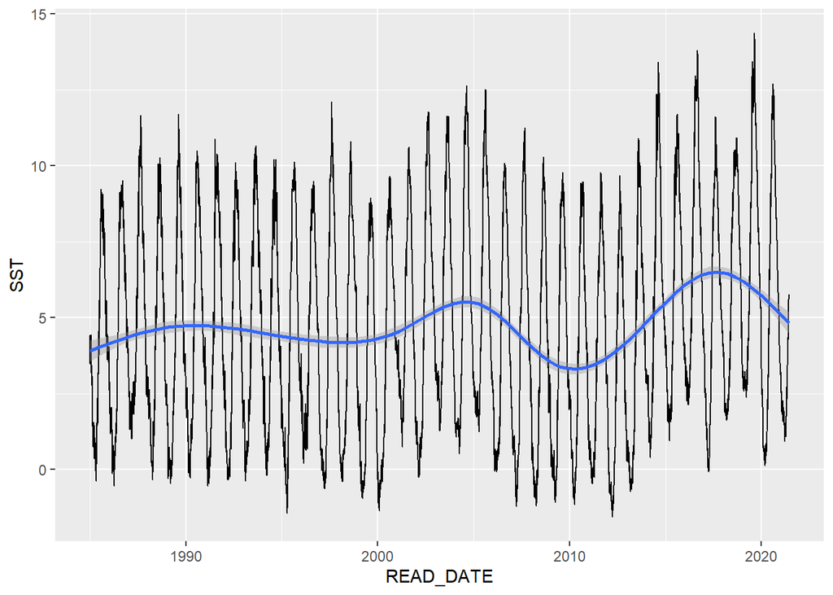

```r
dbFetch(dbSendQuery(con,
                    paste0("select read_date,
                                   round(avg(temp),2) as sst,
                                   crab
                            from afsc.erddap_crw_sst a
                            INNER JOIN (select *
                                      from afsc.erddap_crw_sst_spatial_lookup
                                      where crab = 'bb') b
                            ON a.crw_id = b.id
                            group by
                               crab,
                               read_date"))) %>%
  ggplot(aes(READ_DATE,SST)) +
  geom_line() +
  geom_smooth()
```

Figure DD. Screenshot of a plotted query of Bristol Bay crab management area SST data averaged daily and plotted with default smoothing.